# Session 13 polished lab

Fengling Hu

2021/4/28

# Introduction

Many large cities have housing problems, and the economic and social factors associated with them reflect the current imbalance in regional development. For example, the housing affordability crisis brought about by rising housing prices, but at the same time they are increasing the wealth of homeowners. The challenge for the government is to encourage households to accumulate housing wealth within the region while promoting equity in the housing market. Using census data, this project explores the interconnections between the racial composition of the population, median household income, homeownership rates and housing affordability.

## Description and Goals

The main analysis is carried out in the form of mapping, data and tables, and the spatial distribution of the data allows for a qualitative understanding of the spatial relationships between the data. At the same time, more accurate data is explored to further understand the relationships between the four types of data. It is also possible to understand the checks and balances between the housing market and the population and economy.

# The ACS Data

let’s download some ACS data. Here, I will use the script called “1_Get_ACS.R” already downloaded in the folder.

In this workbook, I will mainly use data related to race, housing tenure, and housing cost burden. These data are collected from the following tables: B02001, B19013, B25003, B25106. So, let’s delete some of the tables that will not be used in this workbook.

Now, what’s left are four tables: - B02001: Race - B19013: Median Household Income - B25003: Housing Tenure (Owners) - B25106: Housing Cost Burden

Combine the four types of data together and observe the results.

Since the current data is based on units of census tracts, it is difficult to visualize the correlation. Next, I am going to plot into a map for further observation.

# The Geographic Data

Since we have already load both the tigris and sf package earlier, now we can download tracts for Illinois into an object called “il_tct”.

Combine the geographic data with exixting acs data:

let’s go ahead and select a subset of these data - the census tracts for the counties that make up the Illinois portion of the Chicago metropolitan area. According to the component of GEOID: - State (2 characters) - County (3 characters) - Tract (6 characters) - Block Group (1 characters)

In order to get data of the Chicago metropolitan area, we need to aggregate tract data into county data, then use group_by to combine data from 9 counties within Chicago area.

filter out two tracts for which ALAND(land area) is 0.

Summarise county-level data related to race, MHHI(median household income), P_Own(housing tenure), CostBurden(house cost)

```
## Simple feature collection with 9 features and 9 fields
## Geometry type: POLYGON
## Dimension:     XY
## Bounding box:  xmin: -88.94215 ymin: 41.10828 xmax: -87.52366 ymax: 42.49564
## Geodetic CRS:  NAD83
## # A tibble: 9 x 10
##   GEOID_CO White_co Black_co AIAN_co Asian_co NonWhite_co MHHI_co P_Own_co CostBurden_co
##   <chr>       <dbl>    <dbl>   <dbl>    <dbl>       <dbl>   <dbl>    <dbl>         <dbl>
## 1 17031       0.529   0.288  2.83e-3  0.0654       0.471   68114.    0.550         0.377
## 2 17037       0.853   0.0712 1.27e-3  0.0195       0.147   62737.    0.578         0.323
## 3 17043       0.771   0.0460 1.91e-3  0.119        0.229   99293.    0.748         0.289
## 4 17063       0.940   0.0113 6.53e-4  0.00938      0.0600  75886.    0.717         0.212
## 5 17089       0.710   0.0607 5.23e-3  0.0355       0.290   78902.    0.702         0.309
## 6 17093       0.821   0.0650 1.52e-3  0.0234       0.179   90148.    0.835         0.285
## 7 17097       0.758   0.0728 3.08e-3  0.0713       0.242  101223.    0.723         0.308
## 8 17111       0.923   0.0148 1.09e-3  0.0260       0.0767  86274.    0.783         0.286
## 9 17197       0.734   0.125  2.65e-3  0.0397       0.266   86699.    0.789         0.288
## # ... with 1 more variable: geometry <POLYGON [arc_degree]>
```

#### Summarise:

```
## # A tibble: 3,123 x 3
##    GEOID       Asian_il MHHI_il
##  * <chr>          <dbl>   <dbl>
##  1 17001000100 0.00105    48088
##  2 17001000201 0.00907    44855
##  3 17001000202 0.000842   50375
##  4 17001000400 0.00906    30164
##  5 17001000500 0.00782    41008
##  6 17001000600 0.00789    54950
##  7 17001000700 0.00614    19869
##  8 17001000800 0.00503    26738
##  9 17001000900 0          46897
## 10 17001001001 0.00230    55708
## # ... with 3,113 more rows
```

Rearranging the rows in descending order of the Asian_il column:

```
## # A tibble: 3,123 x 3
##    GEOID       Asian_il MHHI_il
##    <chr>          <dbl>   <dbl>
##  1 17031841100    0.863   35723
##  2 17031340300    0.815   33333
##  3 17031340400    0.807   50256
##  4 17031840100    0.649   50469
##  5 17031600400    0.623   37786
##  6 17031840200    0.578   61806
##  7 17031803016    0.549  102679
##  8 17019000302    0.546   10385
##  9 17031806003    0.469   68018
## 10 17031350100    0.457   44896
## # ... with 3,113 more rows
```

as shown in the table, there is no obvious relationship between high Asian area and high median household income area.

# Mapping data

#### Mapping Race.

Now take a look at what we can find on the maps.

The distribution of White:

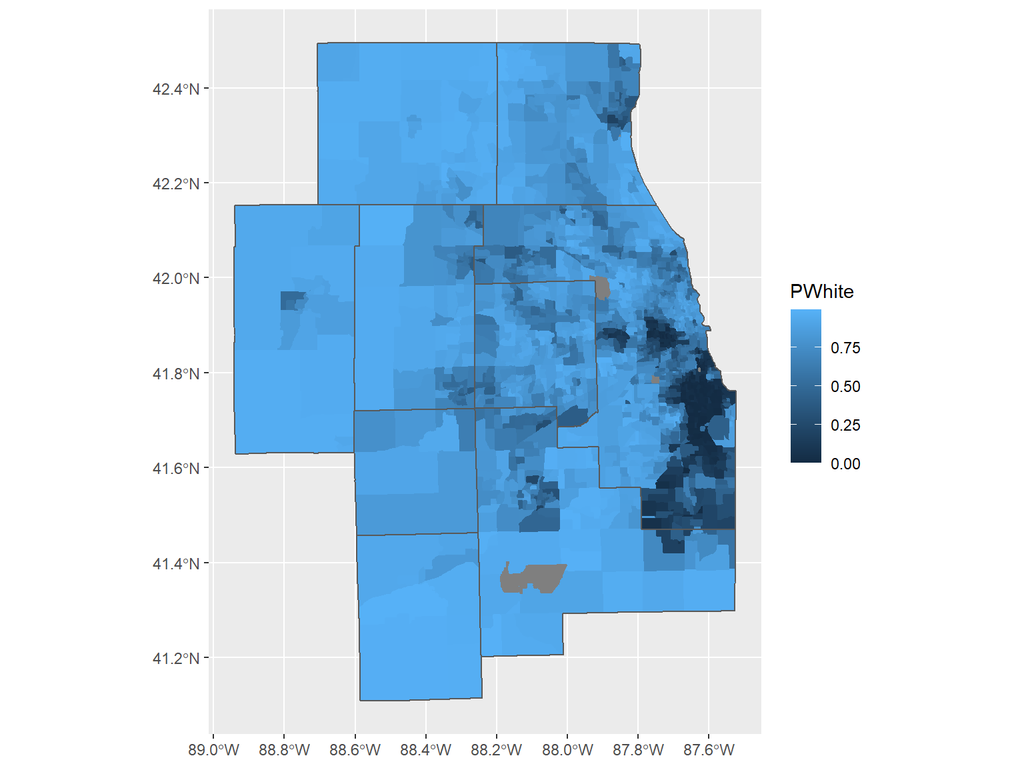

#### Mapping Median household income

The distribution of median household income:

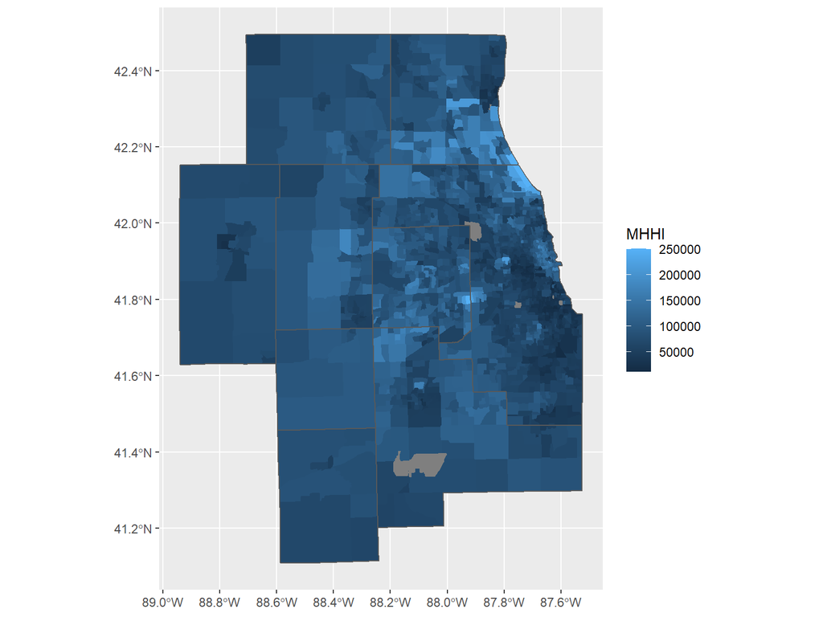

#### Summary:

By comparing the two maps, we can roughly conclude that the regions with more whites have higher median household income. We can only vaguely understand the relationship between these two factors, and subsequently, we need to explore the two other factors - Housing tenure, and housing cost burden, and let us use the same method to understand the spatial distribution characteristics.

#### Mapping Housing tenure

The distribution of house ownership:

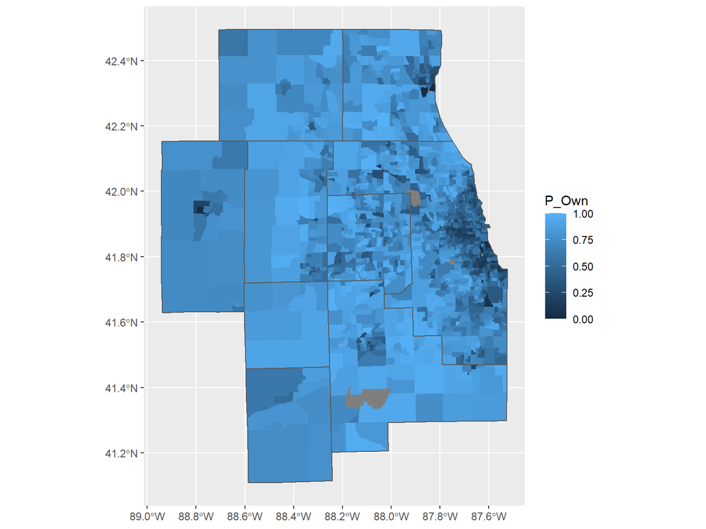

#### Mapping Housing cost burden The distribution of cost burden:

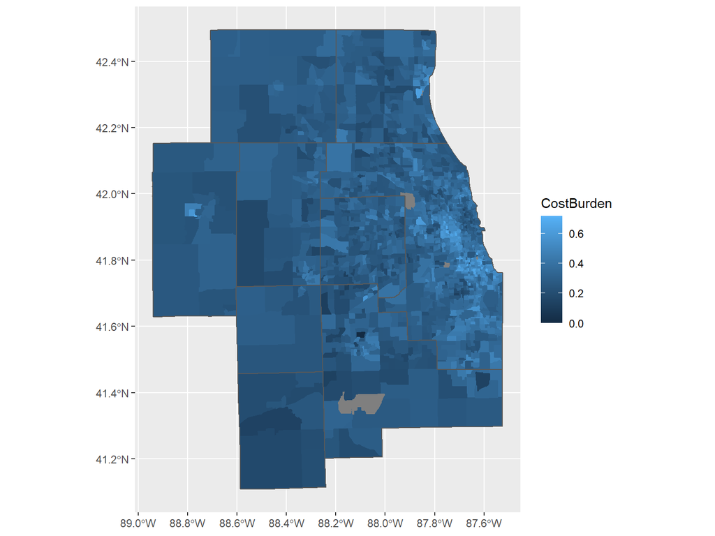

#### Make a histogram of Housing cost burden by different counties

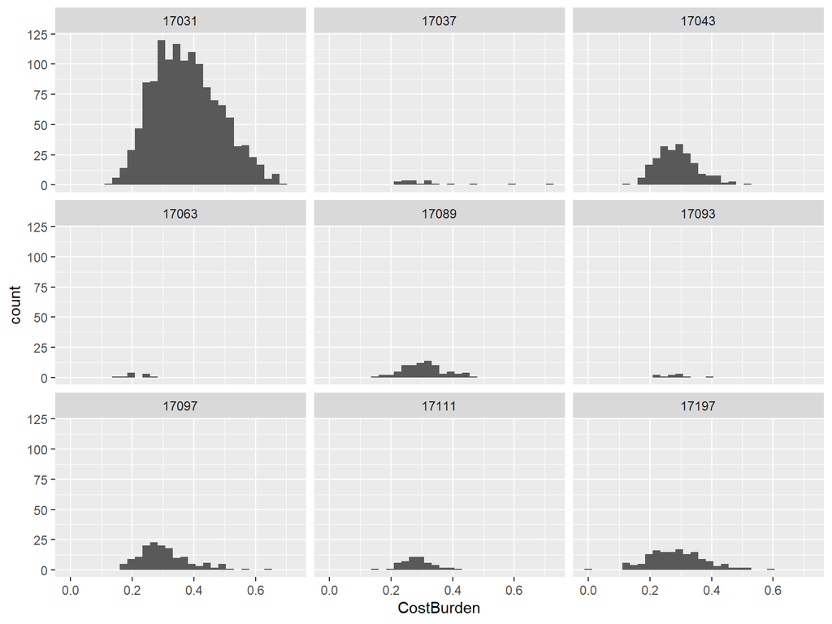

From the diagrams above, it can be seen cook county has the highest housing cost burden.

#### Make a histogram of Housing tenure by different counties

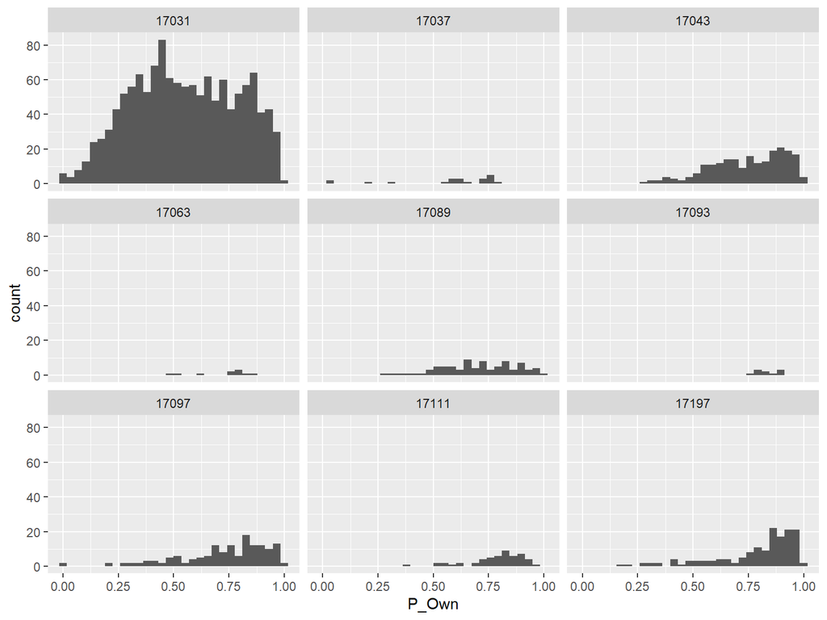

### The relationship between housing tenure and housing cost burden

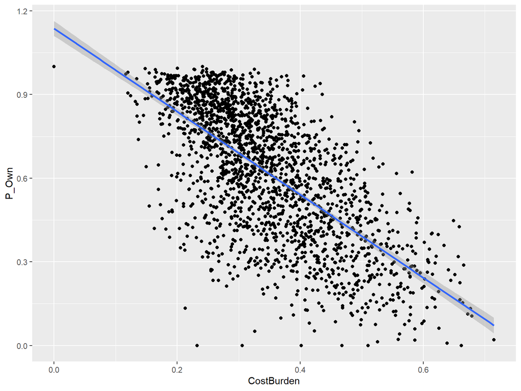

From the diagrams above, we can tell the cost burden is negatively correlated with house ownership. The data concentrated slight above 0.9, which can means most people own one house. the data of cost burden is more evenly distributed among 0 and 0.6.

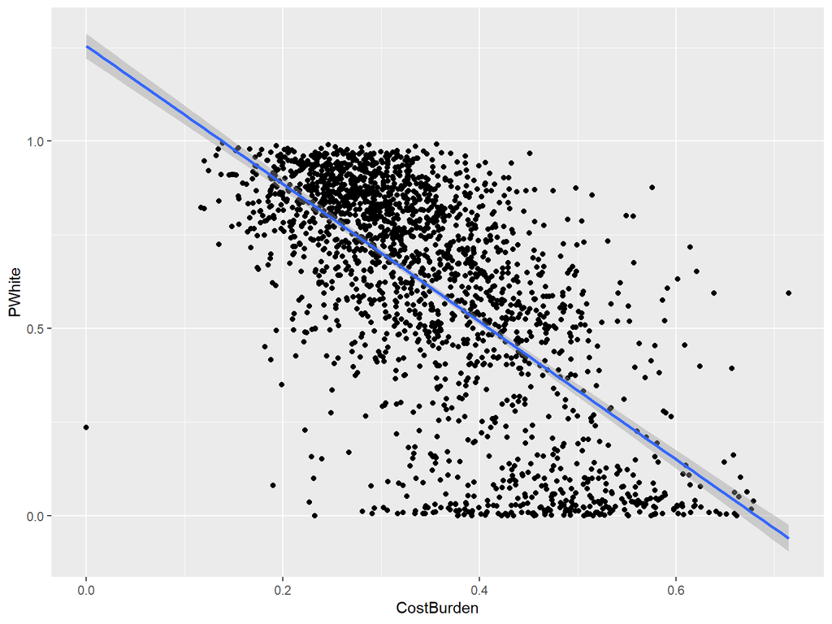

From the diagrams above, we can tell the cost burden is also negatively correlated with the number of white. The two diagrams are quite similar to each other. The data concentrated in two areas, one is slight below 1, one is at 0. This two conentration roughly shows the uneven distribution of white people according to their economic situation. The data of cost burden is evenly distributed among 0 and 0.6.

### Black-White Dissimilarity

```
## Simple feature collection with 9 features and 10 fields
## Geometry type: POLYGON
## Dimension:     XY
## Bounding box:  xmin: -88.94215 ymin: 41.10828 xmax: -87.52366 ymax: 42.49564
## Geodetic CRS:  NAD83
## # A tibble: 9 x 11
##   GEOID_CO dissimilarity                  geometry White_co Black_co AIAN_co Asian_co
##   <chr>            <dbl>    <POLYGON [arc_degree]>    <dbl>    <dbl>   <dbl>    <dbl>
## 1 17031          1031.   ((-88.26359 42.06342, -8~    0.529   0.288  2.83e-3  0.0654
## 2 17037            11.6  ((-88.75359 41.63084, -8~    0.853   0.0712 1.27e-3  0.0195
## 3 17043            84.3  ((-88.26242 41.90012, -8~    0.771   0.0460 1.91e-3  0.119
## 4 17063             4.13 ((-88.59005 41.30374, -8~    0.940   0.0113 6.53e-4  0.00938
## 5 17089            34.7  ((-88.60137 41.99598, -8~    0.710   0.0607 5.23e-3  0.0355
## 6 17093             2.77 ((-88.31928 41.72361, -8~    0.821   0.0650 1.52e-3  0.0234
## 7 17097            91.7  ((-88.19865 42.42002, -8~    0.758   0.0728 3.08e-3  0.0713
## 8 17111            21.6  ((-88.70614 42.43095, -8~    0.923   0.0148 1.09e-3  0.0260
## 9 17197            84.8  ((-88.26088 41.70041, -8~    0.734   0.125  2.65e-3  0.0397
## # ... with 4 more variables: NonWhite_co <dbl>, MHHI_co <dbl>, P_Own_co <dbl>,
## #   CostBurden_co <dbl>
```

# Concluson

There are so many different factors that may influence the housing market. In the workbook, I took a step on the demographic data and related it to the house cost burden and house ownership data. It may not accurately represent the relationship among each other. However, it can allow us to find what’s interesting about those data and dive more into them in the future, such as the race distribution and housing cost burden.